# Phylogenetic Regression and Related Topics

Dean Adams (dcadams@iastate.edu)

2026-04-02

### **Overview**

This tutorial is intended to provide an introduction to the basics of implementing several phylogenetic comparative methods using R. As with previous tutorials, we begin with a brief conceptual overview, which sets the stage for why this is type of analysis is crucial for correct macroevolutionary inference. Then, we go over the basics of reading data and phylogenies into R, evaluating the degree to which phylogenetic signal is present in a continuous trait, and learn three ways to examine bivariate trait associations in continuous data: phylogenetically independent contrasts (PIC), phylogenetic generalized least squares (PGLS), and phylogenetic transformation methods.

### Learning Objectives

- Understand why it is needed to condition trait data on the phylogeny
- be able to conduct phylogenetic regression using either PIC, PGLS, or phylogenetic transformation

### Download data files

To run the analyses in this tutorial, please download the following files from our Git-course repository:

- [Phylogeny](https://github.com/deanadams/MacroevolutionPracticals/blob/main/10-Phylo_Regression/data/Mander.tre)
- [Data1](https://github.com/deanadams/MacroevolutionPracticals/blob/main/10-Phylo_Regression/data/HydromantesMns.csv)
- [Data2](https://github.com/deanadams/MacroevolutionPracticals/blob/main/10-Phylo_Regression/data/PlethodonMns.csv)

Additionally, The R-script for running the code found in this tutorial is found here:

- [RScript](https://github.com/deanadams/MacroevolutionPracticals/blob/main/10-Phylo_Regression/scripts/PhyloRegressionContinuous.r)

Then, on your local computer, place them in a folder named ‘TutorialData’, which is found in the same directory as this tutorial.

#### **Conceptual Background**

First recall why it is necessary to consider the phylogenetic relationships among taxa when performing comparative analyses. In short, because species share an evolutionary history, more closely related species are expected to be similar in their trait values due solely to evolutinary descent. Thus, they cannot be treated as independent observations (they are evolutionarily correlated with one another). This can cause downstream challenges with statistical inference of macroevolutionary patterns.

Numerous analytical methods have been developed to take phylogeny into account, which collectively are termed *phylogenetic comparative methods* (PCMs). DCA prefers to call them the *Phylogenetic Comparative Toolkit*, as a panoply of methods now exists. What links them conceptually is that they all utilize a phylogenetic perspective when evaluating patterns of trait evolution. Mathematically, these methods *condition* the data on the phylogeny during the analysis. Today we will learn how to implement the most commonly used methods for continuous variables: methods for implementing **Phylogenetic Regression**.

### **Illustrating the Problem**

To illustrate the problem with a real-world example, let’s simulate some data phylogenetically and look the correlation of the data before and after conditioning on the phylogeny. This is also a useful skill to learn in R!

```r
set.seed(6679881) ##The n for the largest known Cullen prime. Cullen primes have the form n*(2^n)+1
library(phytools)
```

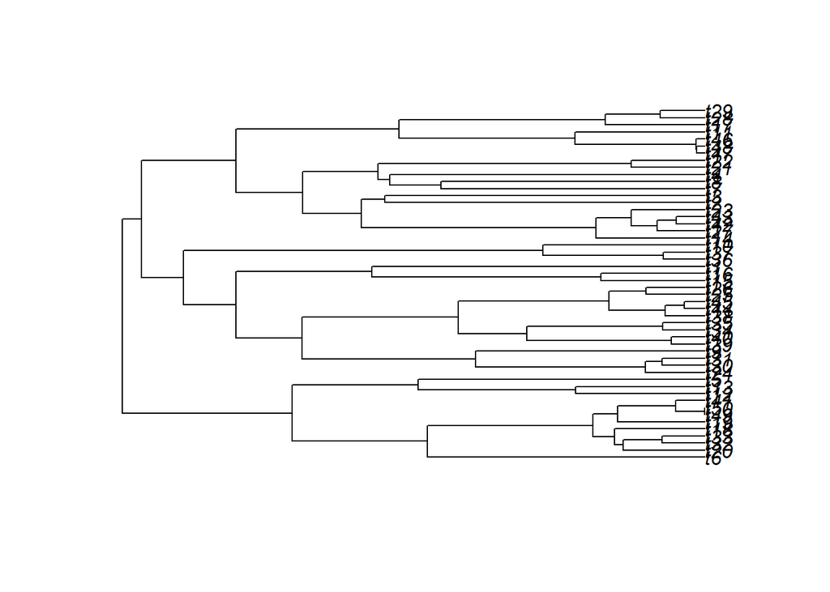

```r
#A quick simulation
mytree<- pbtree(n=50, scale=1) #one way to simulate a tree. Note: in R, one has functions to simulate BD trees, random splits trees, etc. using different functions
plot(mytree)
```

```r
X<-fastBM(tree=mytree) #simulates a continuous trait on phylogeny under Brownian motion
Y<-fastBM(tree=mytree)
cor(X,Y)
```

```
## [1] 0.5381317
```

Without considering phylogeny we can see a correlation of about $0.54$, this is quite large considering the two traits were simulated without any correlation!

Now let’s condition the data on the phylogeny and see look at the correlation between traits. We can use the `pic()` function to make them independent of the phylogeny, alleviating the issue of traits appearing highly correlated even though solely as a result shared ancestry.

**`pic()`**

This function computes the phylogenetically independent contrasts using the method described by Felsenstein (1985). `pic` has two primary arguments:

- $x$ a numeric vector containing the trait values of each species. If the vector is named then values are matched to the labels of `phy`, otherwise the values are assumed to be in the same order of `phy$tip.labels`
- $phy$ a phylo object

This function returns the phlyogenetically independent contrasts of the traits

```r
X_pic <- pic(x=X,phy=mytree)
Y_pic <- pic(x=Y,phy=mytree)
cor(X_pic,Y_pic)
```

```
## [1] 0.07830748
```

Here we have estimated a correlation of approximately $0.08$, that’s notably closer to the true correlation of $0$ when compared to the correlation of the traits without taking the phylogeny into consideration.

### **Bringing Trait Data into R**

Now, say we have our own data and wish to perform a phylogenetic comparative analysis. Our first step is to read the data and the phylogeny into R and ‘link’ them up. This step is crucial, as we need a way to connect the species trait values in the data matrix with the corresponding branches on the phylogeny. Another important step in this process is pruning. It is very common that the phylogeny has more taxa than the data matrix (because one is utilizing a phylogeny from a broad molecular study), or that the data matrix may contain data for species not represented in the phylogeny. Both types of ‘dangling’ taxa must be excised from their respective data objects.

Our first step is to load various R-libraries which contain functions for reading and manipulating phylogenetic datasets. There are many such packages, but the ‘central’ phylogenetics R package is **ape**. As seen earlier, this package has many functions for reading and manipulating phylogenetic trees, as well as numerous quantitative analysis performed in a phylogenetic perspective. Many other phylogenetics-R packages also load *ape* or some of its components.

Also critical for linking up data and a phylogeny is that one must have the species names as a component in the data matrix **EXACTLY** as they are found in the phylogeny (i.e. `names(my_data)` or `rownames(my_data)`, depending on data structure of the trait information, match those on the phylogeny `phy$tip.label`). Luckily, the `treedata()` function can be used to match data to tree with ease, trimming both elements as nessecary.

**`treedata()`**

This function both trims a tree and pruning species from a matrix of trait data such that both elements have the same set of species `treedata` has two primary arguments and two quality of life arguments:

- $phy$ a phylo object
- $data$ a named vector or matrix of continuous trait values, for species in `phy`
- $sort$ a logical for whether `data` should be sorted to match the ordering of names found in `phy` (i.e sort `data` such that the $i^{th}$ row of `data` corresponds to the $i^{th}$ species found in `phy$tip.labels`)
- $warnings$ a logical for whether to report warnings of mismatched taxa between `data` and `phy`

**NOTE:** If the function is provided data containing both (continuous variables) and strings (typically categorical variables), then the output `output$data` will be a matrix with all values converted into strings, which creates issues for functions down the road. We will give an example for how to convert binary categorical variable saved as a string below.

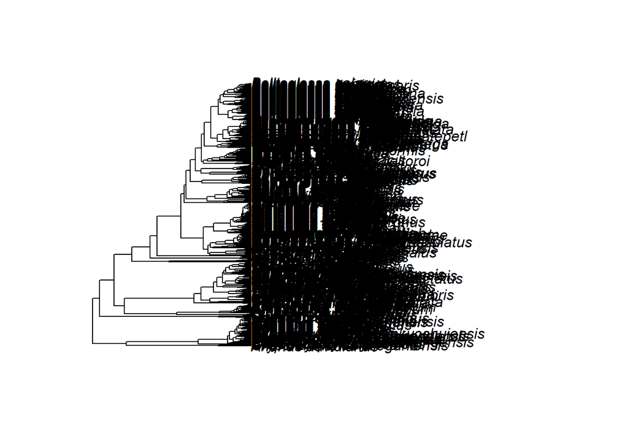

```r
library(ape)
library(geiger)

#Read in data, phylogeny, and match/prune them to one another
ManderTree<-read.tree("../data/Mander.tre",tree.names=T)
plot(ManderTree)
```

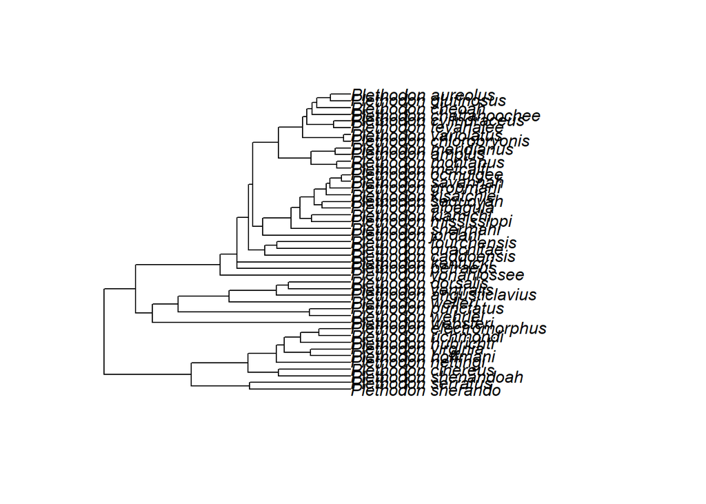

```r
Mander_dat<-read.csv("../data/PlethodonMns.csv", header=TRUE, row.names = 1) #Notice we read in the first column as row.names. These MUST match the names in the phylogeny

Mander_dat[,12]<-(as.numeric(Mander_dat[,12]=="N")) ##Convert the groups from strings to numerics. Treedata doesn't like different types of data.

#Now, prune the tree to match the data and vice-versa:
Pleth_matched<-treedata(phy=ManderTree,data = Mander_dat,sort=T, warnings=FALSE)
plot(Pleth_matched$phy)
```

```r
#grabs appropriate column from data matrix after treedata. We'll use these in analyses later
SVL<-Pleth_matched$data[,1]
HL<-Pleth_matched$data[,3]
BodyW<-Pleth_matched$data[,5]
Fore<-Pleth_matched$data[,6]
Hind<-Pleth_matched$data[,7]
Groups<-as.factor(Pleth_matched$data[,12]);names(Groups)<-rownames(Pleth_matched$data) ##Store the groups and name the vector according to the samples
```

### **Methods for Implementing Phylogenetic Regression**

Now it is time to put it all together and perform a phylogenetic comparative analysis. Using what we have learned, we will use the chronogram and a matrix of quantitative data Plethodontid salamanders. In this case, the data are a set of continuous linear measurements representing morphology. We will perform a bivariate regression of various traits to evaluate the evolutionary association between them, in particular we will be looking at body width (`BodyW`), hindlimb length (`Hind`),forelimb length (`Fore`), head length (`HL`), and body size (`SVL`). However, before we look at the different methods for phylogenetic regression, it may be useful to familiarize ourselves with some of the jargon and functions that are used across methods.

### Models, Regression, and Statistical Tests in R

As we look at the various ways we can implement a phylogenetic regression there will be a lot of new functions and some strange syntax. A lot of the syntax is related to linear models created in R. There are many manipulations that can be done will modeling in R, however, we will be providing a brief and barebones introduction to some of these concepts. You can check out [this](https://doi.org/10.24926/8668/1301) free digital book for a more robust introduction to modeling and regression in R.

First, we will encounter the `~` operator when creating and fitting models in R. The tilde is used to denote the relation between variables. For example, we interpret the expression `Y~X` as a model where variation in `Y` (the dependent variable) depends on variation in `X` (the independent variable). This expression is then used by various functions (e.g. `lm()`, `gls`, `lm.rrpp()`) to fit the linear model, and estimate parameters from it.

Once we have and fit the linear model and obtained estiamtes of its parameters, we may wish to see those estimates and obtain key statistical summary values of the model. The two primary functions used for this are `summary()` and `anova()`. If you’re not familiar with these functions be sure to check out the boxes for each function.

**`summary()`**

This is a very general function for summarizing a lot of different types of R objects, when fit model objects are fed in the function will return summary statistics for parameters. For example:

```r
##Make a linear model with preset data in R
my_linear_model <- lm(cars$dist ~ cars$speed) #Make a model to describe how car speed affects the distance traveled
summary(my_linear_model)
```

[output not shown]

We can see that our model performed a regression and fit a line of the form $Y=\beta X+\epsilon$. For the coefficients we can see the y-intercept (denoted by `(Intercept)`) and the slope (denoted by `cars$speed`) that describes how increases in speed increases in distance. We can see the estimates for these parameters are $-17.5791$ and $3.9324$ respectively. We can assess whether these estimates differ significantly from $0$ by looking at the *p-value* denoted by `Pr(>|t|)`. Since both have very small *p-values*, we might be inclined to say that both the slope and the intercept are nonzero. For the case of a nonzero slop, we then might conclude that car speed does indeed have an impact on the distance traveled.

We can also observe other summary statistics on the bottom, such as the R-squared, F-statistic, and degrees of freedom. The exact layout and statistics shown will change based on the type of object used in the function but generally they will display these statistics.

**`anova()`**

This function performs an **an**alysis **o**f **va**riance for model objects. This suite of tests is often used to assess whether two groups have different means. However, in the case of linear modeling it can be used to test whether the effects (slope parameter) of covariates are nonzero.

```r
##Make a linear model with preset data in R
my_linear_model <- lm(cars$dist ~ cars$speed) #Make a model to describe how car speed affects the distance traveled
anova(my_linear_model)
```

[output not shown]

Here we see how well our coviariate of `cars$speed` does at explaining the response variable `cars$dists`. We can see the F-statistic of $89.567$ and the probability of having an F-statistic at least that extreme under the null model (slope of $0$) is $1.49\times10^{-12}$. We can actually see this is the same F-statistic presented in the `summary()` function. Although the two functions displayed some of the same information, this won’t always be the case for other linear models.

### **Using PIC, PGLS, and Phylogenetic Transformation**

You can click each of the buttons to see how to perform phylogenetic regression under each method. Notice that PIC, PGLS, and Phylo-Transform all yield equivalent results!

#### 0: Phylogenetically-Naive Analysis

First we’ll explore the relationship between hindlimb length (`Hind`) and body width (`BodyW`).

Let’s see what happens when we erroneously don’t account for phylogeny.

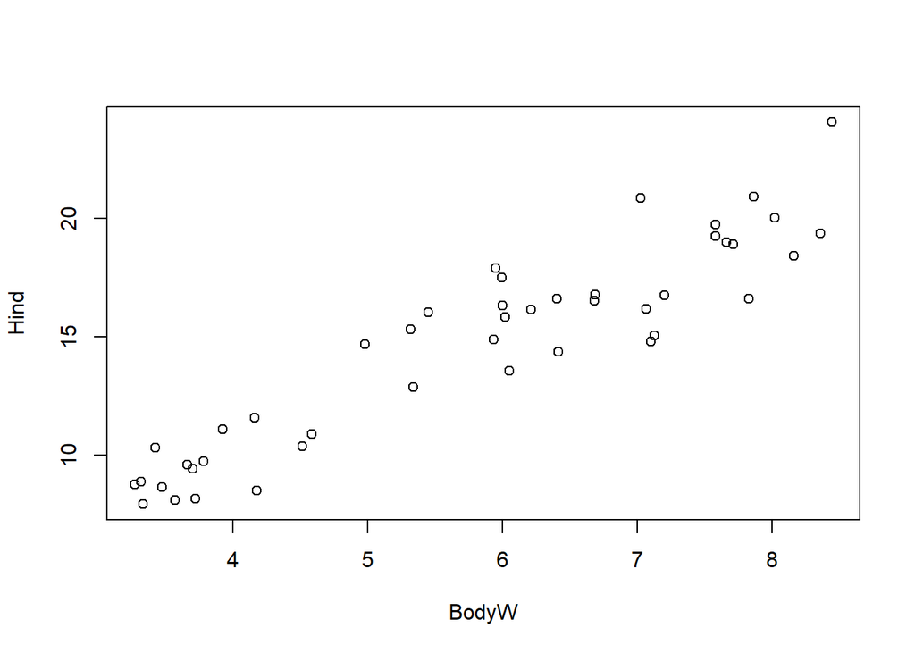

```r
#Phylogenetically-naive analyses
plot(BodyW,Hind)
```

```r
cor.test(Hind,BodyW)  #correlation of two traits: pretty high
```

```
##
##  Pearson's product-moment correlation
##
## data:  Hind and BodyW
## t = 16.546, df = 43, p-value < 2.2e-16
## alternative hypothesis: true correlation is not equal to 0
## 95 percent confidence interval:
##  0.8748508 0.9609558
## sample estimates:
##       cor
## 0.9296516
```

```r
anova(lm(Hind~BodyW))
```

```
## Analysis of Variance Table
##
## Response: Hind
##           Df Sum Sq Mean Sq F value    Pr(>F)
## BodyW      1 685.38  685.38  273.76 < 2.2e-16 ***
## Residuals 43 107.65    2.50
## ---
## Signif. codes:  0 '***' 0.001 '**' 0.01 '*' 0.05 '.' 0.1 ' ' 1
```

#### 1: Phylogenetically Independent Contrasts

Now we’ll look again at the relationship between hindlimb length (`Hind`) and body width (`BodyW`), but first by conditioning on the phylogeny.

Now, let’s recall what PIC does. The approach (Felsenstein 1985) does not perform correlation or regression on the data at the tips of the phylogeny, but rather generates a set of contrast scores at each node of the phylogeny. Under Brownian motion, these are independent of one another and of the phylogeny. One uses the pruning algorithm to work down the phylogeny from tips to root, and obtains a set of N-1 contrasts for N taxa. These are then used in the comparative analysis. The approach is shown conceptually in Fig. 3.

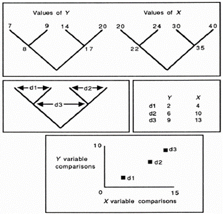

Fig 3. Conceptual figure visualizing the phylogenetically independent contrasts procedure (from Harvey and Pagel, 1991).

Now let’s try this for our dataset:

```r
#Generate PICs and test while conditioning on phylogeny
Hind_pic<-pic(x = Hind, phy = Pleth_matched$phy)
BodyW_pic<-pic(x = BodyW, phy = Pleth_matched$phy)
cor.test(Hind_pic,BodyW_pic)
```

```
##
##  Pearson's product-moment correlation
##
## data:  Hind_pic and BodyW_pic
## t = 8.0398, df = 42, p-value = 4.923e-10
## alternative hypothesis: true correlation is not equal to 0
## 95 percent confidence interval:
##  0.6264769 0.8735296
## sample estimates:
##       cor
## 0.7785548
```

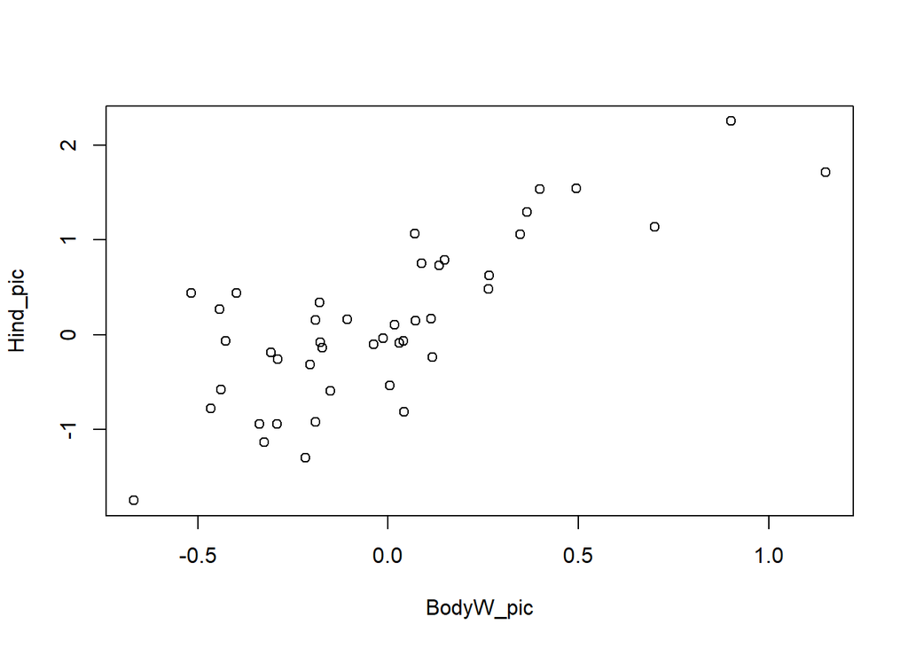

```r
plot(BodyW_pic,Hind_pic)
```

```r
anova(lm(Hind_pic~BodyW_pic+0))   #regression through the origin (b/c order of taxa for contrast is arbitrary [can 'spin' on node])
```

```
## Analysis of Variance Table
##
## Response: Hind_pic
##           Df Sum Sq Mean Sq F value    Pr(>F)
## BodyW_pic  1 18.743 18.7428  59.776 1.142e-09 ***
## Residuals 43 13.483  0.3135
## ---
## Signif. codes:  0 '***' 0.001 '**' 0.01 '*' 0.05 '.' 0.1 ' ' 1
```

```r
summary(lm(Hind_pic~BodyW_pic+0))   #coefficients of the model
```

```
##
## Call:
## lm(formula = Hind_pic ~ BodyW_pic + 0)
##
## Residuals:
##     Min      1Q  Median      3Q     Max
## -0.9146 -0.1847  0.1154  0.5444  1.3564
##
## Coefficients:
##           Estimate Std. Error t value Pr(>|t|)
## BodyW_pic   1.7760     0.2297   7.732 1.14e-09 ***
## ---
## Signif. codes:  0 '***' 0.001 '**' 0.01 '*' 0.05 '.' 0.1 ' ' 1
##
## Residual standard error: 0.56 on 43 degrees of freedom
## Multiple R-squared:  0.5816, Adjusted R-squared:  0.5719
## F-statistic: 59.78 on 1 and 43 DF,  p-value: 1.142e-09
```

We have just performed our first phylogenetic comparative analysis of trait correlation! Our findings are as follows: when conditioned on the phylogeny, there was a significant relationship between hindlimb length and body width. This reveals a strong pattern of evolutionary covariation between the two traits at a macroevolutionary scale.

#### 2: Phylogenetic Generalized Least Squares

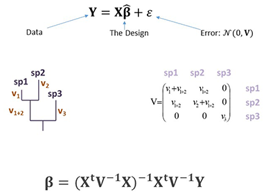

Fig 4. Mathematical description of PGLS.

**`vcv.phylo() and corBrownian()`**

Both of these functions are used to generate the variance-covariance matrix that describes the shared ancestry of the phylogeny. Generally these models assume Brownian motion as a model for generating the matrix $V$, although with some effort `vcv.phylo()` can use different models for trait evolution. These two functions differ in the way that the variance covariance matrix $V$ is formatted. `corBrownian()` generates a structure that is applicable to the robust linear modeling framework already present in R while `vcv.phylo()` simply returns a matrix with variance covariance matrix that is often used in functions developed by folks in the phylogenetics community.

While these functions have a few different arguments, they both really only require one:

- $phy$ a phylo object

**NOTE:** although it is not a required argument for `corBrownian()`, using the `form` argument may come in handy. This argument takes in an expression that denotes the taxa covariate and optionally some grouping factor. At a minimum it can be handy to supply `~species`, where `species` is just a vector with all the species names, this helps the GLS framework match tips on the phylogeny to rows of the data. If nothing is given in the `form` argument then the function will assume that the ordering of tips in the phylogeny is the same row ordering of the data. We can get away luckily without an a `form` argument since the two data structures match as we set `sort=TRUE` in `treedata()` but this may not always be the case.

```r
#To perform PGLS in R, we must first estimate the phylogenetic covariance matrix V (C in matrix form):
spc <- Pleth_matched$phy$tip.label
V<-corBrownian(phy=Pleth_matched$phy,form = ~spc)
C <- vcv.phylo(phy = Pleth_matched$phy)

#Now we run the analysis:
library(nlme)

bm_gls<-gls(Hind ~ BodyW,correlation = V, data=data.frame(Hind, BodyW))
summary(bm_gls)
```

```
## Generalized least squares fit by REML
##   Model: Hind ~ BodyW
##   Data: data.frame(Hind, BodyW)
##        AIC      BIC    logLik
##   176.4589 181.7425 -85.22944
##
## Correlation Structure: corBrownian
##  Formula: ~spc
##  Parameter estimate(s):
## numeric(0)
##
## Coefficients:
##                Value Std.Error  t-value p-value
## (Intercept) 4.036450 1.7021657 2.371362  0.0223
## BodyW       1.775981 0.2297064 7.731524  0.0000
##
##  Correlation:
##       (Intr)
## BodyW -0.645
##
## Standardized residuals:
##         Min          Q1         Med          Q3         Max
## -1.00371099 -0.40278022  0.06018822  0.56516872  1.73144480
##
## Residual standard error: 2.915351
## Degrees of freedom: 45 total; 43 residual
```

```r
anova(bm_gls)
```

```
## Denom. DF: 43
##             numDF  F-value p-value
## (Intercept)     1 92.76129  <.0001
## BodyW           1 59.77646  <.0001
```

#### 3: Phylogenetic Transform

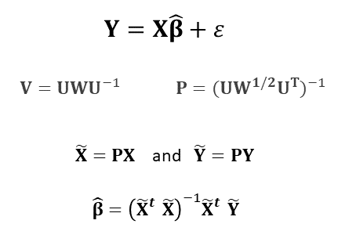

Fig 5. Mathematical description of phylogenetic transformation.

```r
library(RRPP)
##lm.rrpp, the function used to create the model, requires the data in a specific format. rrpp.data.frame puts the data in that format. It is essentially a data frame in a specific format.
rdf<-rrpp.data.frame(Hind=as.matrix(Hind),BodyW=as.matrix(BodyW),Groups=as.matrix(Groups), C=C)
res.PhyT<-lm.rrpp(Hind~BodyW, data = rdf, Cov = C, print.progress = FALSE)
anova(res.PhyT)
```

```
##
## Analysis of Variance, using Residual Randomization
## Permutation procedure: Randomization of null model residuals
## Number of permutations: 1000
## Estimation method: Generalized Least-Squares (via OLS projection)
## Sums of Squares and Cross-products: Type I
## Effect sizes (Z) based on F distributions
##
##           Df     SS      MS     Rsq      F      Z Pr(>F)
## BodyW      1 18.743 18.7428 0.58162 59.776 4.3794  0.001 ***
## Residuals 43 13.483  0.3135 0.41838
## Total     44 32.225
## ---
## Signif. codes:  0 '***' 0.001 '**' 0.01 '*' 0.05 '.' 0.1 ' ' 1
##
## Call: lm.rrpp(f1 = Hind ~ BodyW, data = rdf, Cov = C, print.progress = FALSE)
```

```r
res.PhyT$LM$gls.coefficients ## the estimated coefficients of the model
```

```
##                 [,1]
## (Intercept) 4.036450
## BodyW       1.775981
```

### Related Topics

#### Phylogenetic ANOVA

In addition to the three implementations of phylogenetic regression reviewed above, there are several other related analyses of interest. Perhaps the most obvious is performing analysis of variance (ANOVA) in a phylogenetic framework. There are two options. First, one may use the simulation procedure of Garland et al. (1993). This approach to ‘phylogenetic anova’ does *NOT* condition the analysis on the phylogeny, but rather uses an OLS ANOVA to obtain a statistical summary for the observed data, and then generates a set of possible response (Y) data via phylogenetic simulation; where traits are simulated on the phylogeny under a Brownian motion model (as above). OLS ANOVA is then performed on each simulated dataset, from which the F-ratios are obtained. This generates a distribution of possible F-values against which the observed is compared. **As shown in lecture, results from this approach do not match those of PGLS, and so this implementation should not be used (see Adams and Collyer 2022).**

```r
aov.phylo(SVL~Groups, phy = Pleth_matched$phy) ##Not the same analysis
```

```
## Analysis of Variance Table
##
## Response: dat
##           Df Sum-Sq Mean-Sq  F-value  Pr(>F) Pr(>F) given phy
## group      1    9.4   9.441 0.069719 0.79301           0.7822
## Residuals 43 5823.1 135.421
```

```
##
## Call:
## lm(formula = dat ~ group)
##
## Coefficients:
## (Intercept)       group1
##      58.142        1.036
```

A second procedure using phylogenetic transformation and permutation (RRPP). Here the data are first conditioned on the phylogeny and an ANOVA performed. This approach is identical to that used in phylogenetic regression via transformation as per above. Then, permutation of residuals is used to assess significance (RRPP: Adams and Collyer, 2018). One can also use gls for univariate analsyes:

```r
anova(lm.rrpp(SVL~Groups, data = rdf, Cov = C, print.progress = FALSE))
```

```
##
## Analysis of Variance, using Residual Randomization
## Permutation procedure: Randomization of null model residuals
## Number of permutations: 1000
## Estimation method: Generalized Least-Squares (via OLS projection)
## Sums of Squares and Cross-products: Type I
## Effect sizes (Z) based on F distributions
##
##           Df     SS     MS     Rsq      F       Z Pr(>F)
## Groups     1  19.72 19.716 0.04296 1.9303 0.99932  0.168
## Residuals 43 439.21 10.214 0.95704
## Total     44 458.93
##
## Call: lm.rrpp(f1 = SVL ~ Groups, data = rdf, Cov = C, print.progress = FALSE)
```

```r
anova(gls(SVL~Groups,correlation = V, data=data.frame(SVL, Groups)))  #identical to Phylo.transform
```

```
## Denom. DF: 43
##             numDF  F-value p-value
## (Intercept)     1 48.38985  <.0001
## Groups          1  1.93026  0.1719
```

Remember, phylogenetic ANOVA via simulation (Garland et al. 1993) does *not* condition the data on the phylogeny. It uses OLS ANOVA followed by BM simulations for possible results. This is why the F-ratio differs in the first method above as compared to the other two approaches (PGLS and phylogenetic transform). Recall also from lecture that the distribution of F-ratios and significance levels, do not match using the Garland et al. procedure. However, the latter two methods *do* condition the data on the phylogeny during the analysis, and match one another perfectly.

#### Additional Simulation Approaches

Sometimes we may wish to simulate data with a known correlation between traits under Brownian motion. In this case, we cannot simulate each trait separately, as that is tantamount to simulating data with no correlation.

In the non-phylogenetic (OLS) world, simulating such data is accomplished using an input covariance matrix. The following is an example:

```r
####Additional Simulation Approaches
#Simulate correlated data
library(MASS)
R<-matrix(0.7, nrow=2,ncol=2); diag(R)<-1 ## This matrix desribes the covariation between traits
R
```

```
##      [,1] [,2]
## [1,]  1.0  0.7
## [2,]  0.7  1.0
```

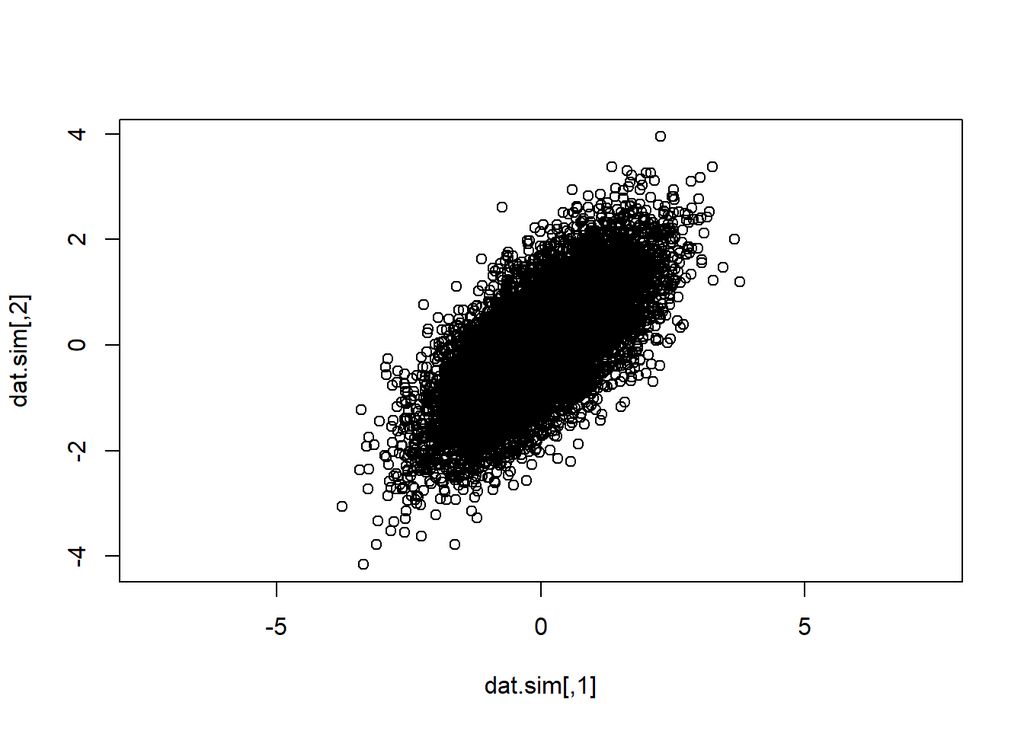

```r
dat.sim<-mvrnorm(n=10000,Sigma = R,mu = c(0,0))
plot(dat.sim, asp=1)
```

To simulate correlated traits under Brownian motion on a phylogeny, we use the function ‘sim.char’:

```r
#Simulate BM correlated data on phylogeny
mytree<- pbtree(n=100, scale=1) #one way to simulate a tree
R<-matrix(0.7, nrow=2,ncol=2); diag(R)<-1 ## This matrix describes the covariation between traits
R
```

```
##      [,1] [,2]
## [1,]  1.0  0.7
## [2,]  0.7  1.0
```

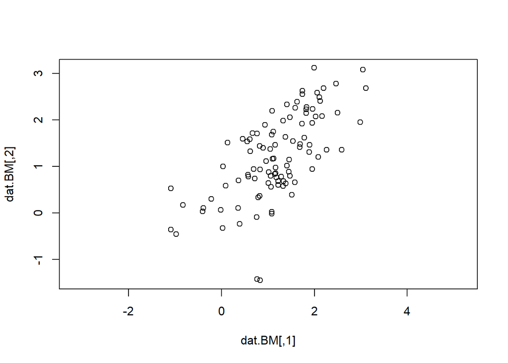

```r
dat.BM<-sim.char(phy = mytree,par = R,nsim = 1)[,,1]
plot(dat.BM, asp=1)
```